# Bella Beat Case Analyze

# Calculate percentage of each user type

```r
user_type_percent <- user_type_summary %>%
  group_by(user_type) %>%
  summarise(total_count = n()) %>%
  mutate(total_participants = sum(total_count)) %>%
  mutate(percentage = round(total_count / total_participants * 100, 1))

print(user_type_percent)
```

```
## # A tibble: 3 × 4
##   user_type     total_count total_participants percentage
##   <chr>               <int>              <int>      <dbl>
## 1 Active                 18                 33       54.5
## 2 Highly Active           7                 33       21.2
## 3 Sedentary               8                 33       24.2
```

### 6.3 Analyzing Trends by Day of the Week

# Identifying which days are the most active vs. the most sedentary.

```r
weekday_analysis <- daily_activity %>%
  group_by(day_of_week) %>%
  summarize(
    avg_steps = mean(total_steps),
    avg_calories = mean(calories),
    avg_sedentary_mins = mean(sedentary_minutes)
  ) %>%
  arrange(desc(avg_steps))

print(weekday_analysis)
```

```
## # A tibble: 7 × 4
##   day_of_week avg_steps avg_calories avg_sedentary_mins
##   <ord>           <dbl>        <dbl>              <dbl>
## 1 Saturday        8153.        2355.               964.
## 2 Tuesday         8125.        2356.              1007.
## 3 Monday          7781.        2324.              1028.
## 4 Wednesday       7559.        2303.               989.
## 5 Friday          7448.        2332.              1000.
## 6 Thursday        7406.        2200.               962.
## 7 Sunday          6933.        2263                990.
```

### 6.4 Merging Activity and Sleep Data

# To see if there is a correlation between physical activity and sleep quality.

# First, align date column names for the merge

```r
daily_sleep <- daily_sleep %>%
  rename(activity_date = sleep_day)
```

# Perform inner join (only keeping records where both activity and sleep exist)

```r
combined_data <- merge(daily_activity, daily_sleep, by = c("id", "activity_date"))
```

# Calculate correlation between steps and sleep

```r
correlation_value <- cor(combined_data$total_steps, combined_data$total_minutes_asleep)
cat("Correlation between Steps and Sleep:", correlation_value, "\n")
```

```
## Correlation between Steps and Sleep: -0.1903439
```

# ——————————————————————————

# 7. KEY FINDINGS (Preliminary Observations)

# ——————————————————————————

# 1. Average daily steps are around 7,600, which is below the recommended 10,000.

# 2. Sedentary minutes average ~991 (over 16 hours!), indicating a high degree of inactivity.

# 3. Participants sleep an average of 419 minutes (~7 hours).

# 4. Preliminary check: There is a very weak correlation between steps and sleep

# duration in this specific dataset.

# ——————————————————————————

# 8. SHARE PHASE (Data Visualization)

# ——————————————————————————

### 8.1 Distribution of User Types

# This chart helps Bellabeat understand their audience segments.

# Knowing that a large portion is “Active” but not “Highly Active”

# suggests a need for motivational features.

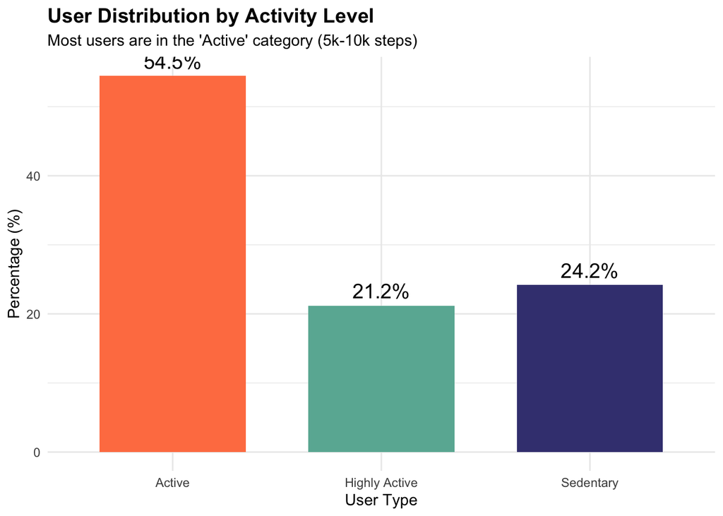

### 8.2 Daily Steps by Day of the Week

# Identifying when users are most active helps Bellabeat time their

# marketing notifications and social media engagement.

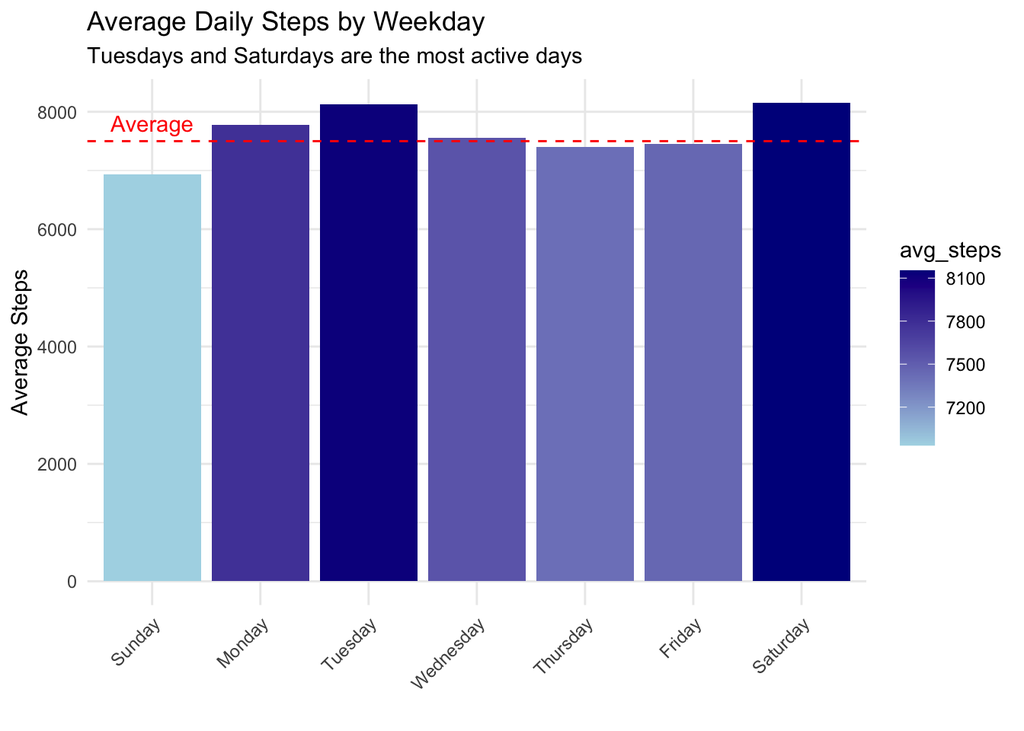

### 8.3 Relationship: Total Steps vs. Calories

# This scatter plot confirms the positive correlation between movement

# and energy expenditure. This validates the core value of Bellabeat trackers.

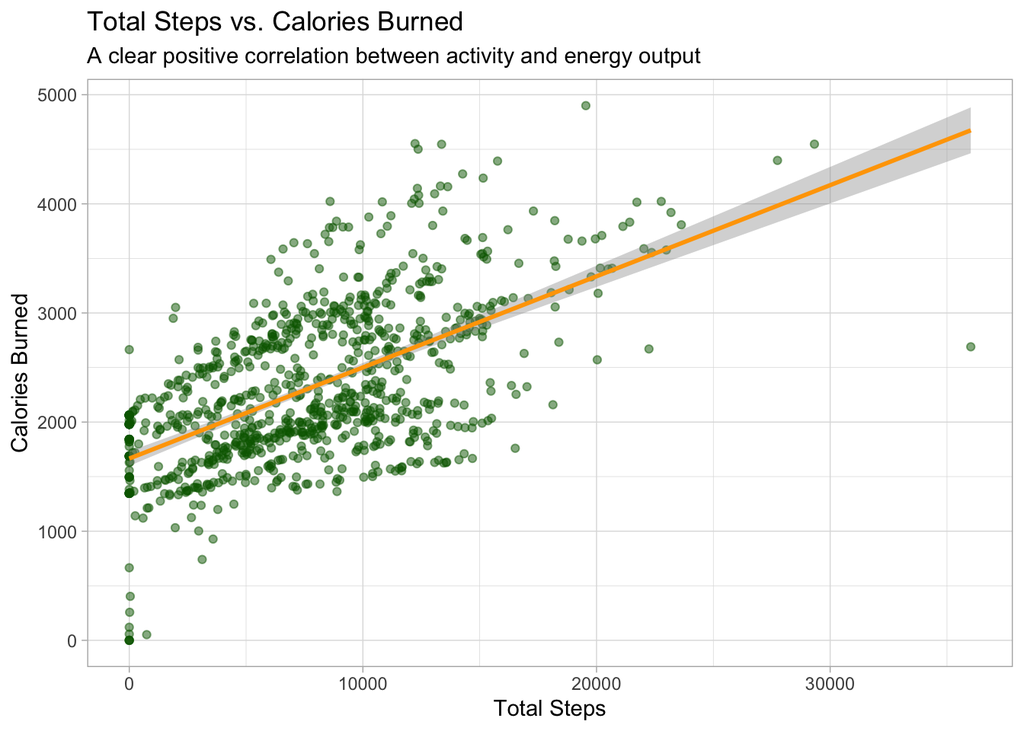